# Midterm 2 Practice: Part II (Answers)

S352

Fall 2025

## Q1: WWE Universal Championship

(a).

```r
WWE <- c(1, 188, 28, 504, 64, 156, 98, 28, 81, 119, 27.5, 150.5, 7, 757)
# Exponential
1 / mean(WWE)
```

```
## [1] 0.006337709
```

For the Exponential, MLE of $\lambda$ is $\hat{\lambda} \approx 0.00634$.

(b).

```r
# Gamma
x.bar <- mean(WWE)
sigma2.hat <- mean(WWE^2) - x.bar^2
# Fit a gamma
gamma.nll <- function(pars, data){
  k <- pars[1]
  lambda <- pars[2]
  lik <- dgamma(data, k, lambda)
  return(-sum(log(lik)))
}
k.mom <- x.bar^2 / sigma2.hat
lambda.mom <- x.bar / sigma2.hat
gamma.mle <- optim(par = c(k.mom, lambda.mom), fn = gamma.nll, data = WWE, hessian = TRUE)
gamma.mle$par
```

```
## [1] 0.662793943 0.004200934
```

```r
sqrt(diag(solve(gamma.mle$hessian)))
```

```
## [1] 0.204397082 0.001741776
```

For the gamma, I got $\hat{k} = 0.663$ and $\hat{\lambda} = 0.0042$, with standard errors of $0.204$ and $0.0017$ respectively.

(c). Wald test for H0 : k = 1

```r
gamma.var <- solve(gamma.mle$hessian)
w <- (gamma.mle$par[1] - 1)^2 / gamma.var[1, 1]
w
```

```
## [1] 2.721707
```

```r
1 - pchisq(w, df = 1)
```

```
## [1] 0.09899211
```

(d). LR test for H0 : k = 1

```r
# LL: gamma
llg <- -gamma.nll(gamma.mle$par, data = WWE)
llg
```

```
## [1] -83.93121
```

```r
# or
llg_2 <- -gamma.mle$value
llg_2
```

```
## [1] -83.93121
```

```r
# LL: expo
lle <- sum(log(dexp(WWE, 1/mean(WWE))))
lle
```

```
## [1] -84.85733
```

```r
# LR test stat
LR <- 2*(llg - lle)
1 - pchisq(LR, df = 1)
```

```
## [1] 0.1735236
```

A likelihood ratio test gives a $P$-value of about 0.17. There isn’t enough evidence to reject the Exponential hypothesis.

(e).

```r
# AIC: gamma
2*gamma.mle$value + 2*2
```

```
## [1] 171.8624
```

```r
# AIC: expo
-2*sum(log(dexp(WWE, 1/mean(WWE)))) + 2*1
```

```
## [1] 171.7147
```

AICs are very close, indicating these two models have about the same performance. Exponential model has slightly lower AIC, and therefore is fitting the data a bit better.

## Q2: Florida crime

(a).

```r
FloridaCrime <- read.table("FloridaCrime.txt", header = TRUE)
crime.lmA <- lm(Crime ~ HS, data = FloridaCrime)
crime.lmA
```

```
##
## Call:
## lm(formula = Crime ~ HS, data = FloridaCrime)
##
## Coefficients:
## (Intercept)           HS
##     -50.857        1.486
```

The equation can be written as

$$\textrm{Crimes per 1000 residents} = -50.86 + 1.486 \times
\textrm{percent with high school education} + \textrm{error}$$

or
$$\textrm{Predicted crime rate} = -50.86 + 1.486 \times \textrm{percent
with high school education}$$
(b).

```r
crime.lmB <- lm(Crime ~ HS + Urban, data = FloridaCrime)
crime.lmB
```

```
##
## Call:
## lm(formula = Crime ~ HS + Urban, data = FloridaCrime)
##
## Coefficients:
## (Intercept)           HS        Urban
##     59.1181      -0.5834       0.6825
```

The regression equation is
$$\textrm{Predicted crime rate} = 59.11 - 0.583 \times \textrm{percent
with high school education} + 0.683 \times \textrm{urban percentage}$$
or
$$\textrm{Crimes per 1000 residents} = 59.11 - 0.583 \times
\textrm{percent with high school education} + 0.683 \times \textrm{urban
percentage} + \textrm{error}$$

(c). The easiest way to quantitatively compare the models is by using AIC:

```r
AIC(crime.lmA)
```

```
## [1] 626.0932
```

```r
AIC(crime.lmB)
```

```
## [1] 601.8526
```

The model with both high school and urban percentages has a clearly lower AIC, so we would guess it would be better for predictive purposes. (Alternatively you could split data into training and test set and compare the MSEs.)

(c). The positive coefficient for high school in (a) means counties with more high school education tend to have *higher* crime rates. The effect is statisticallt significant.

```r
summary(crime.lmA)
```

```
##
## Call:
## lm(formula = Crime ~ HS, data = FloridaCrime)
##
## Residuals:
##    Min     1Q Median     3Q    Max
## -43.74 -21.36  -4.82  17.42  82.27
##
## Coefficients:
##             Estimate Std. Error t value Pr(>|t|)
## (Intercept) -50.8569    24.4507  -2.080   0.0415 *
## HS            1.4860     0.3491   4.257 6.81e-05 ***
## ---
## Signif. codes:  0 '***' 0.001 '**' 0.01 '*' 0.05 '.' 0.1 ' ' 1
##
## Residual standard error: 25.12 on 65 degrees of freedom
## Multiple R-squared:  0.218,  Adjusted R-squared:  0.206
## F-statistic: 18.12 on 1 and 65 DF,  p-value: 6.806e-05
```

We can also see this clearly from a scatterplot:

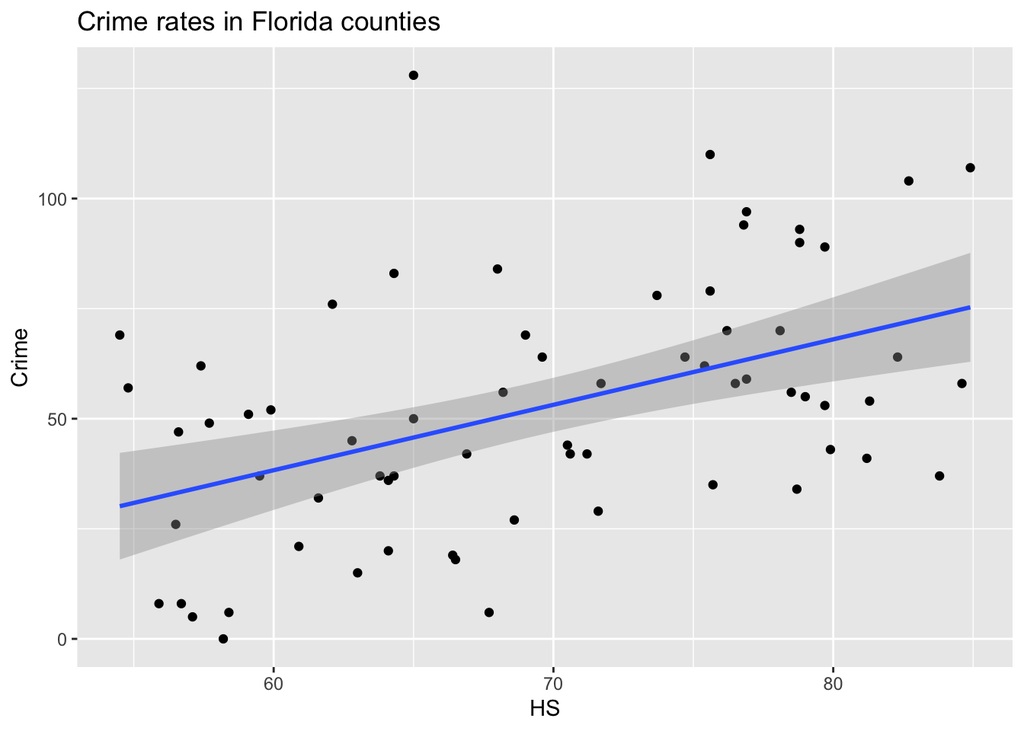

```r
ggplot(FloridaCrime, aes(x = HS, y = Crime)) + geom_point() + geom_smooth(method = "lm") + ggtitle("Crime rates in Florida counties")
```

However, the coefficient for high school becomes negative in the model for (b). Roughly, this means that for counties with the same urban percentage, counties with more high school education will have *lower* predicted crime rates (though the effect is not statistically significant.)

```r
summary(crime.lmB)
```

```
##
## Call:
## lm(formula = Crime ~ HS + Urban, data = FloridaCrime)
##
## Residuals:
##     Min      1Q  Median      3Q     Max
## -34.693 -15.742  -6.226  15.812  50.678
##
## Coefficients:
##             Estimate Std. Error t value Pr(>|t|)
## (Intercept)  59.1181    28.3653   2.084   0.0411 *
## HS           -0.5834     0.4725  -1.235   0.2214
## Urban         0.6825     0.1232   5.539 6.11e-07 ***
## ---
## Signif. codes:  0 '***' 0.001 '**' 0.01 '*' 0.05 '.' 0.1 ' ' 1
##
## Residual standard error: 20.82 on 64 degrees of freedom
## Multiple R-squared:  0.4714, Adjusted R-squared:  0.4549
## F-statistic: 28.54 on 2 and 64 DF,  p-value: 1.379e-09
```

If you look more closely at the data (which for this exercise you were not required to), you’ll find that the effect is driven mostly by counties that are very highly urban. In particular, Dade County (where Miami is) is 98.8% urban and has the highest crime rate in Florida, while being below average in high school education.

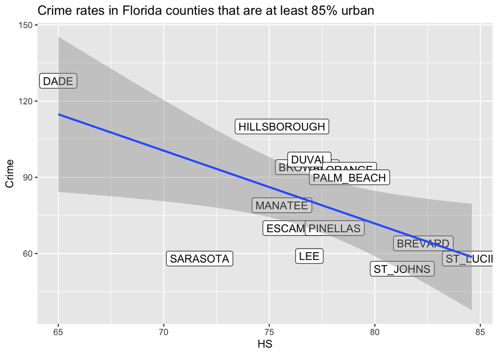

```r
FloridaCrime |> filter(Urban > 85) |>
  ggplot(aes(x = HS, y = Crime, label = County)) + geom_label() + geom_smooth(method = "lm") + ggtitle("Crime rates in Florida counties that are at least 85% urban")
```

One possible explanation (though not the only possible one) for all this is that urban percentage is the far more important determinant of crime rates – urban areas have more opportunities for (reportable) crimes than rural areas. In comparison, perhaps education doesn’t matter as much.

## Q3: Biochemists

(a). The MLE for $\lambda$ is just the sample mean.

```r
biochemists <- read.table("biochemists.txt", header = TRUE)
lambda.hat <- mean(biochemists$art)
lambda.hat
```

```
## [1] 1.692896
```

So we can model the number of articles as having a Poisson distribution with parameter $\lambda = 1.69$.

(b). We can copy-paste the `pois0.nll()` function from earlier in the course.

```r
pois0.nll <- function(pars, data){
  p <- pars[1]
  lambda <- pars[2]
  pois.lik <- dpois(data, lambda)
  real.lik <- rep(NA, length(data))
  which0 <- (data == 0)
  real.lik[which0 == FALSE] <- (1 - p) * pois.lik[which0 == FALSE]
  real.lik[which0 == TRUE] <- p + (1 - p) * pois.lik[which0 == TRUE]
  loglik <- log(real.lik)
  return(-sum(loglik))
}
```

Now apply it to `biochemists$art`:

```r
art.zip <- optim(par = c(mean(biochemists$art == 0), mean(biochemists$art)), fn = pois0.nll, data = biochemists$art)
art.zip$par
```

```
## [1] 0.2066511 2.1339491
```

I get MLEs of $\hat{p} = 0.207$ and $\hat{\lambda} = 2.13$.

We can compare the models using AIC:

```r
# Poisson model
pois.ll <- sum(log(dpois(biochemists$art, lambda.hat)))
-2 * pois.ll + 2 * 1
```

```
## [1] 3487.147
```

```r
# ZIP model
2 * art.zip$value + 2 * 2
```

```
## [1] 3362.782
```

The zero-inflated model has the lower AIC (and doesn’t have implausible parameter estimates), so it’s better by that criterion.

Alternatively, you could simulate from the Poisson and zero-inflated Poisson models, and verify that the zero-inflated model gives results that look more like the raw data.

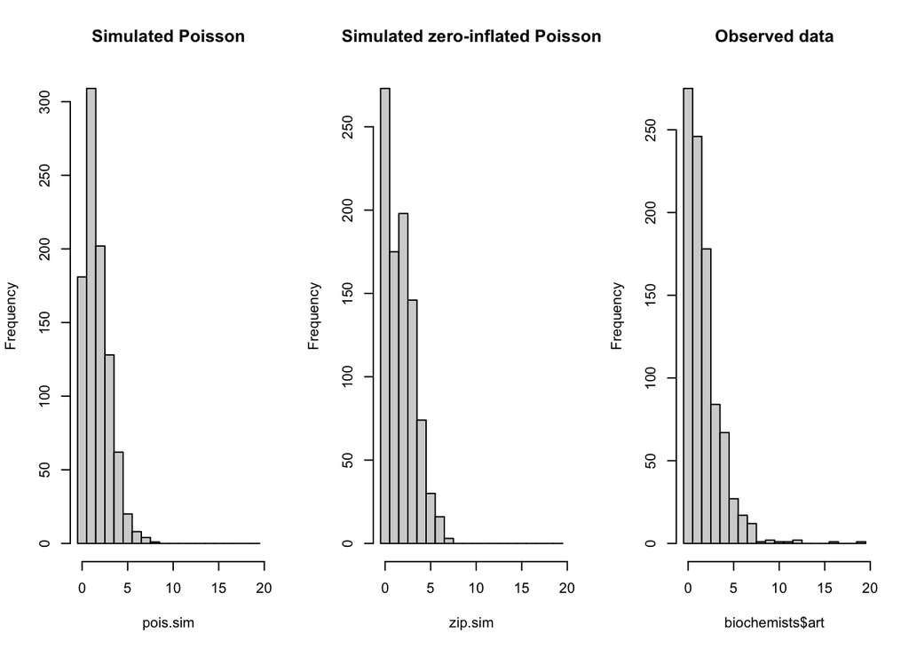

```r
set.seed(352)
pois.sim <- rpois(915, lambda.hat)
zip.sim <- rpois(915, art.zip$par[2])
zeroes <- rbinom(915, 1, art.zip$par[1])
zip.sim <- (1 - zeroes) * zip.sim
par(mfrow = c(1, 3))
hist(pois.sim, breaks = seq(-0.5, 19.5, 1), main = "Simulated Poisson")
hist(zip.sim, breaks = seq(-0.5, 19.5, 1), main = "Simulated zero-inflated Poisson")
hist(biochemists$art, breaks = seq(-0.5, 19.5, 1), main = "Observed data")
```

```r
par(mfrow = c(1, 1))
```

Neither of the models is perfect – both fail to capture that there are some extreme cases where somehow people manage to produce ten or more articles in three years. However, at least the zero-inflated model correctly captures that more than a quarter of the students produced no articles at all.

(c).

```r
nokid <- subset(biochemists, kid5 == 0)
nokid.zip <- optim(par = c(mean(nokid$art == 0), mean(nokid$art)), fn = pois0.nll, data = nokid$art, hessian = TRUE)
nokid.zip$par
```

```
## [1] 0.1958819 2.1405415
```

```r
sqrt(diag(solve(nokid.zip$hessian)))
```

```
## [1] 0.02265433 0.07885619
```

```r
kid <- subset(biochemists, kid5 > 0)
kid.zip <- optim(par = c(mean(kid$art == 0), mean(kid$art)), fn = pois0.nll, data = kid$art, hessian = TRUE)
kid.zip$par
```

```
## [1] 0.2268417 2.1199106
```

```r
sqrt(diag(solve(kid.zip$hessian)))
```

```
## [1] 0.03200907 0.11047270
```

For students with no children 5 or younger, the ZIP has MLEs $\hat{p} = 0.196$ and $\hat{\lambda} = 2.14$. For students with at least one child 5 or younger, the ZIP has MLEs $\hat{p} = 0.226$ and $\hat{\lambda} = 2.12$. If we take this literally, it implies that having a child 5 or younger increases your probability of producing zero articles, and even if you do produce something, it very slightly reduces the number of articles you produce. However, the differences between the models are not too big compared to the standard errors, so we shouldn’t be too certain about this.

## Q4: Crabs

(a).

```r
crabs <- read.table("crabs.txt", header = TRUE)
crabs.lmA <- lm(SpermTotal ~ Mass, data = crabs)
crabs.lmA
```

```
##
## Call:
## lm(formula = SpermTotal ~ Mass, data = crabs)
##
## Coefficients:
## (Intercept)         Mass
##    16.79024      0.00319
```

```r
AIC(crabs.lmA)
```

```
## [1] 997.3144
```

The regression equation is
$$\textrm{SpermTotal} = 16.79 + 0.00319 \times \textrm{Mass} +
\textrm{error}$$

with AIC 997.3.

(b).

```r
crabs.lmB <- lm(SpermTotal ~ Mass + Location, data = crabs)
crabs.lmB
```

```
##
## Call:
## lm(formula = SpermTotal ~ Mass + Location, data = crabs)
##
## Coefficients:
##       (Intercept)               Mass   LocationDelaware      LocationMaine
##         18.597190           0.001035           1.301277          -1.916908
##    LocationSapelo        LocationSHK  LocationWellfleet
##          0.974363          -0.412806          -1.275529
```

where the location terms are added if and only if the crab comes from that location.

```r
AIC(crabs.lmB)
```

```
## [1] 945.5006
```

The AIC is 945.5, less than for model (a).

(c).

```r
crabs.lmC <- lm(SpermTotal ~ Mass + Location + Mass:Location, data = crabs)
```

Here are the regression coefficients of the interaction model (there’s no point writing them all out manually):

```r
crabs.lmC
```

```
##
## Call:
## lm(formula = SpermTotal ~ Mass + Location + Mass:Location, data = crabs)
##
## Coefficients:
##            (Intercept)                    Mass        LocationDelaware
##              16.334833                0.003743                5.444406
##          LocationMaine          LocationSapelo             LocationSHK
##               1.028798                1.655901                1.225441
##      LocationWellfleet   Mass:LocationDelaware      Mass:LocationMaine
##               1.795535               -0.004557               -0.004472
##    Mass:LocationSapelo        Mass:LocationSHK  Mass:LocationWellfleet
##              -0.001616               -0.001504               -0.003865
```

```r
AIC(crabs.lmC)
```

```
## [1] 944.9238
```

The AIC is 944.9, very slightly lower than the model in (b).

(d).

```r
BIC(crabs.lmA)
```

```
## [1] 1007.973
```

```r
BIC(crabs.lmB)
```

```
## [1] 973.9243
```

```r
BIC(crabs.lmC)
```

```
## [1] 991.1122
```

Which model is best? I think you could choose either (b) or (c). (c) has the lowest AIC, but only by a bit, and it might be overfitting. (b) has a decent AIC, and the lowest BIC, and makes sense.

(e).

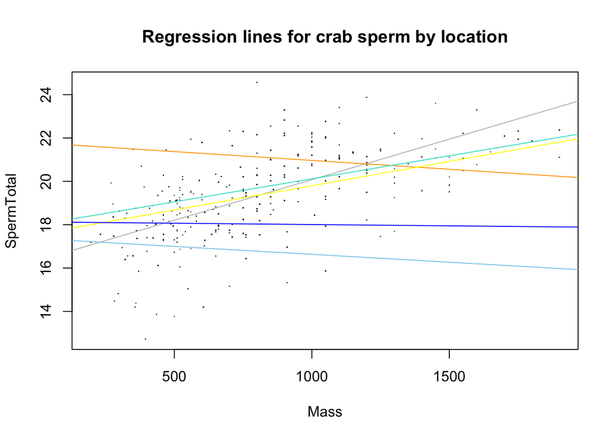

```r
ints <- coef(crabs.lmC)[1] + c(0, coef(crabs.lmC)[3:7])
slopes <- coef(crabs.lmC)[2] + c(0, coef(crabs.lmC)[8:12])
colors <- c("grey", "orange", "skyblue", "turquoise", "yellow", "blue")

# use basic plot function

plot(crabs$Mass, crabs$SpermTotal, pch = ".",
     xlab = "Mass",
     ylab = "SpermTotal",
  main = "Regression lines for crab sperm by location")
abline(ints[1], slopes[1], col = colors[1])
abline(ints[2], slopes[2], col = colors[2])
abline(ints[3], slopes[3], col = colors[3])
abline(ints[4], slopes[4], col = colors[4])
abline(ints[5], slopes[5], col = colors[5])
abline(ints[6], slopes[6], col = colors[6])
```

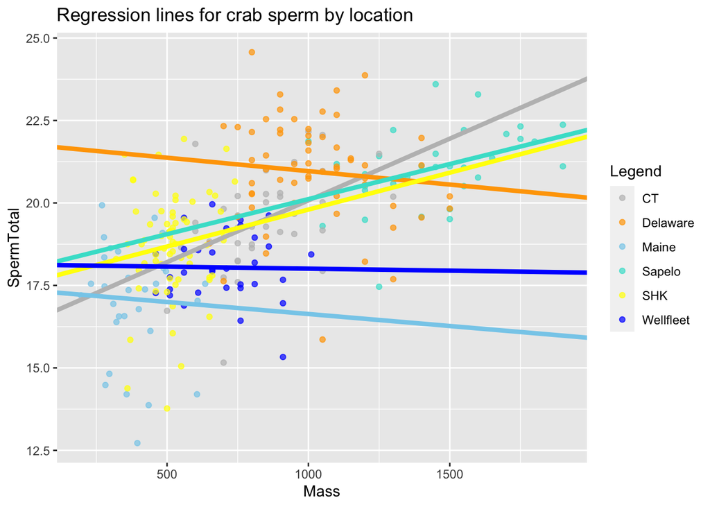

```r
# use ggplot

ggplot(crabs, aes(x = Mass, y = SpermTotal, color = Location)) +
  geom_point(alpha = 0.7) +
  geom_abline(intercept = ints, slope = slopes, color = colors, linewidth = 1.5) +
  ggtitle("Regression lines for crab sperm by location") +
  labs(color = "Legend") +
  scale_color_manual(values = colors)
```

Does this look questionable? I don’t know. It seems a bit weird that the lines for Delaware and Maine clearly go down – I would’ve though that larger crabs would have higher sperm counts regardless of location. But then I’m not very knowledgeable about crab reproduction.

## Q5: Fall 2024 Midterm 2 Exam Question

1. Exponential model is better as it has a lower AIC, 836.1503 vs 837.5869.
2. W = 0.5893562. p-value: 0.4426682. Fail to reject H0.
3. LR test stat: 0.5633861. p-value: 0.4528991. Fail to reject H0.

(Code is similar to the above in Q1.)